# Regression Project

Vishal Reddy Mekala

2022-12-04

The structure of the dataset looks like this.  
Luckily the data was mostly cleaned, we just had to make some minor alterations.

```
##     charges           age            sex                 bmi
##  Min.   : 1122   Min.   :18.00   Length:1338        Min.   :15.96
##  1st Qu.: 4740   1st Qu.:27.00   Class :character   1st Qu.:26.30
##  Median : 9382   Median :39.00   Mode  :character   Median :30.40
##  Mean   :13270   Mean   :39.21                      Mean   :30.66
##  3rd Qu.:16640   3rd Qu.:51.00                      3rd Qu.:34.69
##  Max.   :63770   Max.   :64.00                      Max.   :53.13
##     children        smoker             region
##  Min.   :0.000   Length:1338        Length:1338
##  1st Qu.:0.000   Class :character   Class :character
##  Median :1.000   Mode  :character   Mode  :character
##  Mean   :1.095
##  3rd Qu.:2.000
##  Max.   :5.000
```

## EXPLORATORY DATA ANALYSIS:

As one would have expected, we can infer from the below plot that smokers tend to pay more charges than non-smokers. Most of the non-smokers from the data tend to pay less than $20,000.

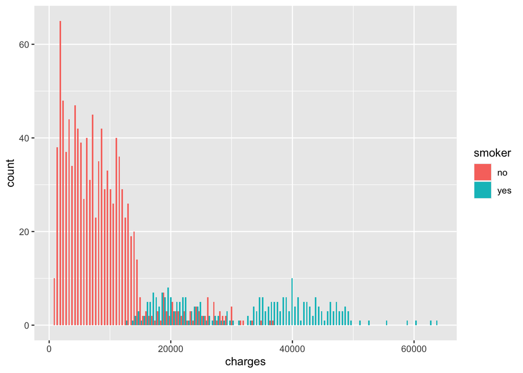

Looking at the below plot, we can understand that for smokers, insurance charges and bmi have a linear relationship, whereas for non-smokers, bmi doesn’t seem to effect much how much they are charged.  
Most of the non-smokers are roughly charged less than $20,000.

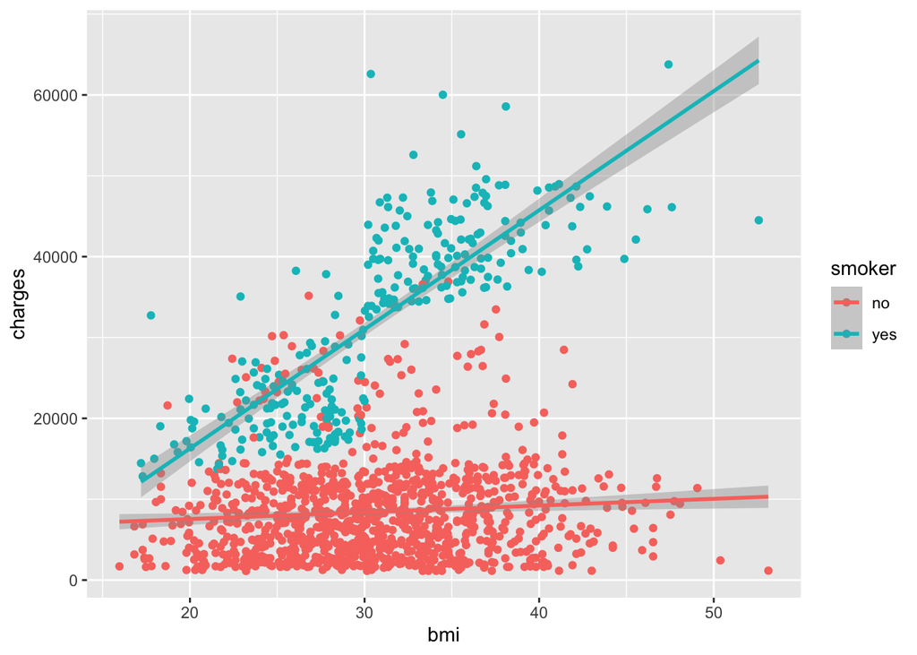

Looks like people in the southeast on average, have roughly 10% higher bmi than people in other regions and this difference is more noticeable specially in men.

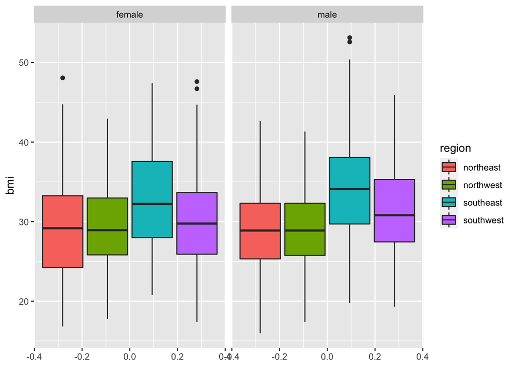

Out of personal interest, I want to see if we have any smokers under the age of 20.

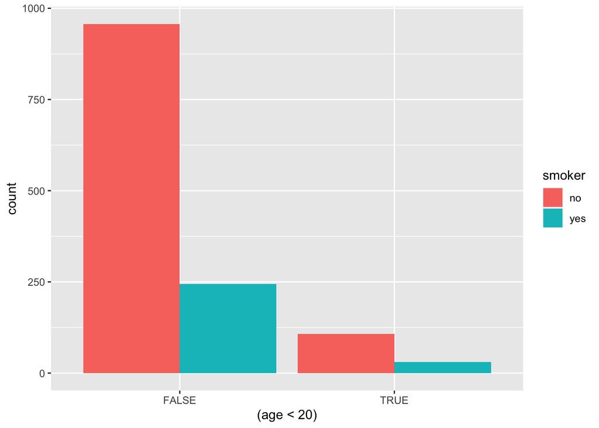

Looks like we do have some young smokers here.  
Does smoking have anything to do with premiums even at the age of 20? Let’s check!!

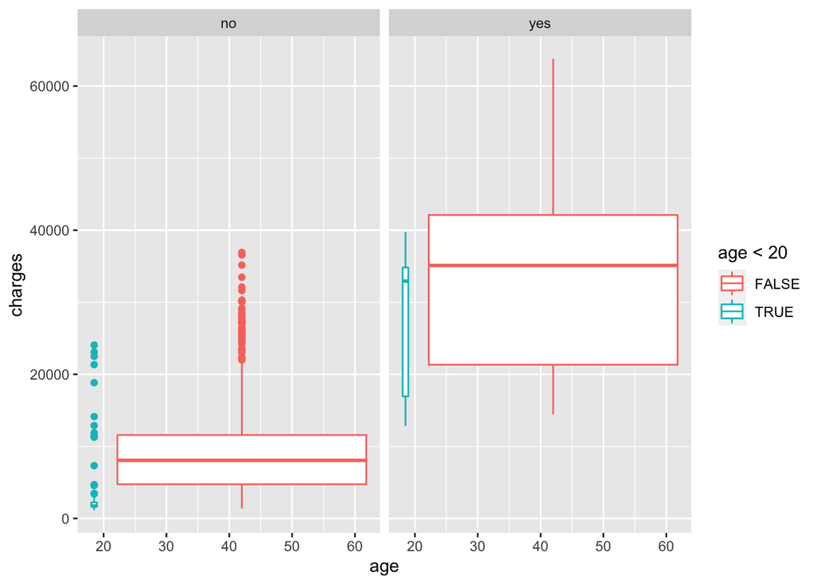

Not what I was expecting but smokers under the age of 20 also seem to be billed more than young non-smokers.

## BASE MODEL

Firstly, let’s split our dataset into training and testing sets for regression analysis.  
But before fitting a regression model, since our dataset has more categorical variables than numeric variables, for ease of  
interpretability, I’d like to perform dummy encoding.  
I am going to do this only on the “region” predictor since it has 4 levels. The other categorical variables are just going to be factored into two levels each.  
The region variable is now divided into 3 separate columns.  
(1,0,0) indicates region= “Northeast”  
(0,1,0) indicates region= “Northwest”  
(0,0,1) indicates region= “Southeast”  
(0,0,0) indicates region= “Southwest”

```
## Classes 'data.table' and 'data.frame':   1338 obs. of  9 variables:
##  $ charges  : num  16885 1726 4449 21984 3867 ...
##  $ age      : int  19 18 28 33 32 31 46 37 37 60 ...
##  $ sex      : Factor w/ 2 levels "female","male": 1 2 2 2 2 1 1 1 2 1 ...
##  $ bmi      : num  27.9 33.8 33 22.7 28.9 ...
##  $ children : int  0 1 3 0 0 0 1 3 2 0 ...
##  $ smoker   : Factor w/ 2 levels "no","yes": 2 1 1 1 1 1 1 1 1 1 ...
##  $ northeast: num  0 0 0 0 0 0 0 0 1 0 ...
##  $ northwest: num  0 0 0 1 1 0 0 1 0 1 ...
##  $ southeast: num  0 1 1 0 0 1 1 0 0 0 ...
##  - attr(*, ".internal.selfref")=<externalptr>
```

Dividing the data into 75% as training data and 25% as testing data:

```r
set.seed(111)
sample <- sample.int(n = nrow(insur), size = floor(.75*nrow(insur)), replace = F)
train <- insur[sample, ]
test  <- insur[-sample, ]
rm(sample)
```

**FITTING THE BASE REGRESSION MODEL NOW:**

```
##
## Call:
## lm(formula = charges ~ ., data = train)
##
## Residuals:
##    Min     1Q Median     3Q    Max
## -11117  -2890  -1019   1402  29779
##
## Coefficients:
##              Estimate Std. Error t value Pr(>|t|)
## (Intercept) -13421.38    1160.99 -11.560  < 2e-16 ***
## age            257.23      13.49  19.066  < 2e-16 ***
## sexmale        179.53     377.75   0.475 0.634699
## bmi            336.85      32.71  10.299  < 2e-16 ***
## children       515.45     154.58   3.335 0.000886 ***
## smokeryes    23436.79     469.68  49.899  < 2e-16 ***
## northeast     1038.83     534.69   1.943 0.052313 .
## northwest     1121.40     543.01   2.065 0.039167 *
## southeast      816.86     536.14   1.524 0.127930
## ---
## Signif. codes:  0 '***' 0.001 '**' 0.01 '*' 0.05 '.' 0.1 ' ' 1
##
## Residual standard error: 5946 on 994 degrees of freedom
## Multiple R-squared:  0.757,  Adjusted R-squared:  0.7551
## F-statistic: 387.2 on 8 and 994 DF,  p-value: < 2.2e-16
```

**HYPOTHESIS TESTING:**  
Let’s try to answer some of the questions below:  
1) Are the variables even related to our response variable?  
This question can be answered by looking at the last line of the summary. The F-statistic has a value of 387.2 and the p-value is 2.2e-16 which is statistically significant at a significance level 0.05. This tells us that the predictors do have a relationship with our response-charges.  
2) Does sex of a person effect their charges?  
H_0 : beta_2 = 0  
H_A : beta_2!= 0  
From the above summary table, the p-value for the coefficient of sex is “0.634699”.  
This large value is definitely not statistically significant at level 0.05. Therefore, we fail to reject the null hypothesis.  
We can conclude by saying that there is not enough statistical evidence to state that “sex of a person effects their insurance charges”

**MODEL EVALUATION:**  
The overall model explains about 75% variation of the data and has a p-value of 2.2e-16, indicating interaction of terms is linked to the response variable, although some of the individual variables are not statistically significant.

Let’s see how this model performs on training set and testing set.

```
## [1] 5919.581
```

```
## [1] 6449.704
```

Both our RMSE(train and test) are close to each other but a roughly $6500 error indicates that the model might not have the best accuracy. This means that on average our model incorrectly measures a value by +- $6500.

I suspect that the test/train split is a possible reason for these big numbers. The k-fold cross-validation can tell us if I’m right.

## BASE MODEL- Linear Regression with 10-fold Cross Validation :

```
## Linear Regression
##
## 1338 samples
##    6 predictor
##
## No pre-processing
## Resampling: Cross-Validated (10 fold)
## Summary of sample sizes: 1204, 1204, 1205, 1205, 1203, 1205, ...
## Resampling results:
##
##   RMSE      Rsquared  MAE
##   6070.305  0.749644  4204.238
##
## Tuning parameter 'intercept' was held constant at a value of TRUE
```

```
##
## Call:
## lm(formula = .outcome ~ ., data = dat)
##
## Residuals:
##      Min       1Q   Median       3Q      Max
## -11304.9  -2848.1   -982.1   1393.9  29992.8
##
## Coefficients:
##                 Estimate Std. Error t value Pr(>|t|)
## (Intercept)     -11938.5      987.8 -12.086  < 2e-16 ***
## age                256.9       11.9  21.587  < 2e-16 ***
## sexmale           -131.3      332.9  -0.394 0.693348
## bmi                339.2       28.6  11.860  < 2e-16 ***
## children           475.5      137.8   3.451 0.000577 ***
## smokeryes        23848.5      413.1  57.723  < 2e-16 ***
## regionnorthwest   -353.0      476.3  -0.741 0.458769
## regionsoutheast  -1035.0      478.7  -2.162 0.030782 *
## regionsouthwest   -960.0      477.9  -2.009 0.044765 *
## ---
## Signif. codes:  0 '***' 0.001 '**' 0.01 '*' 0.05 '.' 0.1 ' ' 1
##
## Residual standard error: 6062 on 1329 degrees of freedom
## Multiple R-squared:  0.7509, Adjusted R-squared:  0.7494
## F-statistic: 500.8 on 8 and 1329 DF,  p-value: < 2.2e-16
```

**REGRESSION DIAGNOSTICS:**  
Let’s test the assumptions of linear regression now.  
**Constant Variance:**  
This is a type of plot that displays the fitted values of the regression model along the x-axis and the residuals of those fitted values along the y-axis.  
If the spread of the residuals is roughly equal at each level of the fitted values, we say that the constant variance assumption is satisfied. But in this case, the points seem to be in clusters thereby violating our constant variance assumption.

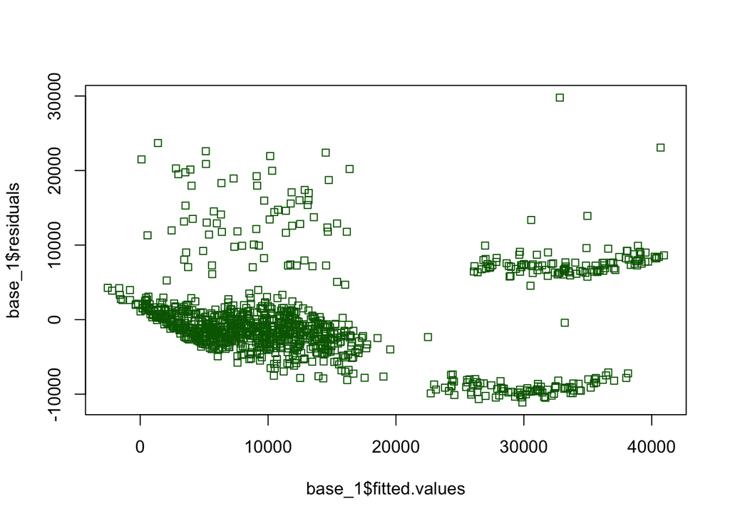

I suspect there is some predictor that is causing us these clusters. At this point, I think we all know what predictor it is.  
TADAAAA

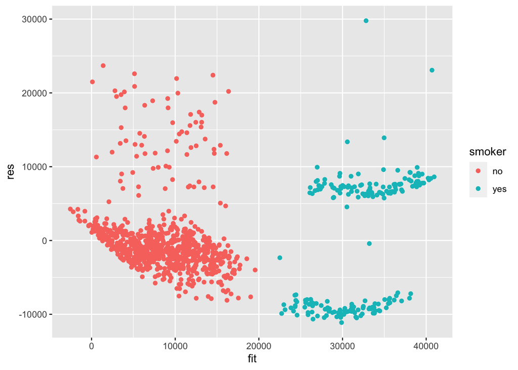

**Linearity:** Interestingly, bmi seems to be non-linear. Maybe log/sqrt transformations would work but that would cost us interpretebability.

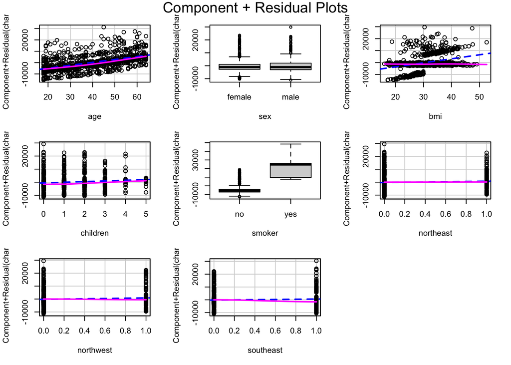

**Normality:**  
Looking at the below plots,and the results from the Shapiro test, normal distribution of the residuals is definitely not observed.  
Hence, normality assumption is violated as well.

```
##
##  Shapiro-Wilk normality test
##
## data:  residuals(base_1)
## W = 0.90393, p-value < 2.2e-16
```

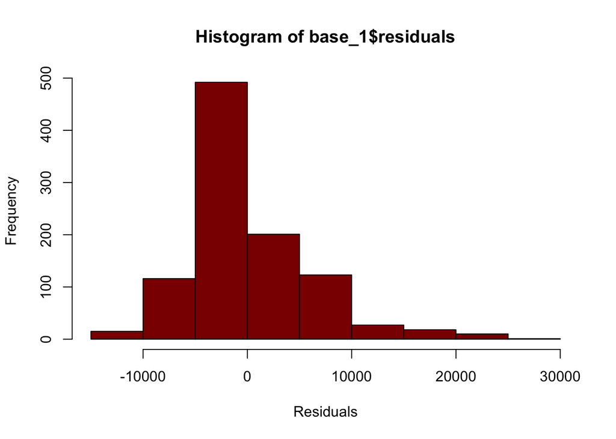

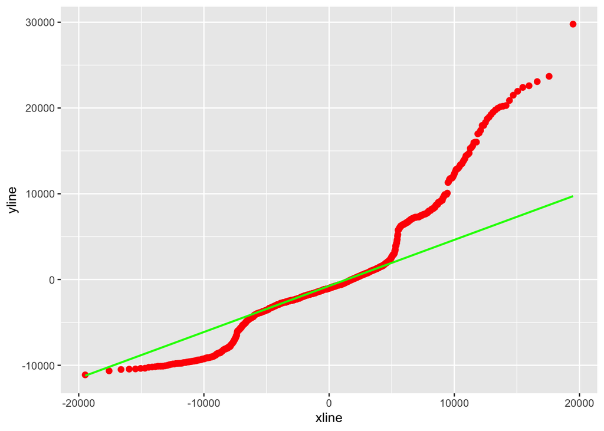

**Multicollinearity:**  
A VIF test will check the multicollinearity between variables in the model.

```
##       age       sex       bmi  children    smoker northeast northwest southeast
##  1.022053  1.011724  1.126322  1.003156  1.013885  1.529612  1.504975  1.592767
```

From the above output, none of the values are >5, so we can say that our predictors are not correlated.

Based on our regression diagnostics and accuracy tests, it is understood that linear regression might not be the ideal solution for this problem.  
There is more scope to this, possibly by adding interaction of variables or implementing other algorithms.

## LINEAR REGRESSION- With interaction terms

The categorical variables are converted to numeric columns here for variable interaction purposes. The initial model(one with a lot of interactions) has been reduced to a simpler model.  
Using AIC as criterion and performing stepwise backward selection, the best model with interactions has the following variables:

```
##    (Intercept)            age            bmi       children         smoker
##       14693.18         227.00       -1236.17         932.59      -18295.82
##   `age:region` `sex:children`   `bmi:smoker`   `bmi:region`
##          15.25        -275.38        1358.99         -35.19
```

**MODEL EVALUATION**  
This model explains about 84% of the data and on predicting the test data, we have arrived at RMSE= 4913. This is definitely a significant reduction from our initial model. At this point, we have successfully built an accurate model but at the cost of the interpretability. On running the diagnostic tests on this model, it has not complied with the assumptions of linear regression. Therefore, we have decided to move to tree-based algorithms.

```
## [1] 0.8405982
```

```
## [1] 4913.225
```

## DECISION TREE REGRESSOR

Below is the decision tree model for the same dataset. The main advantage of trees is its interpretability. Anyone without prior knowledge in data science can easily understand what’s happening here.

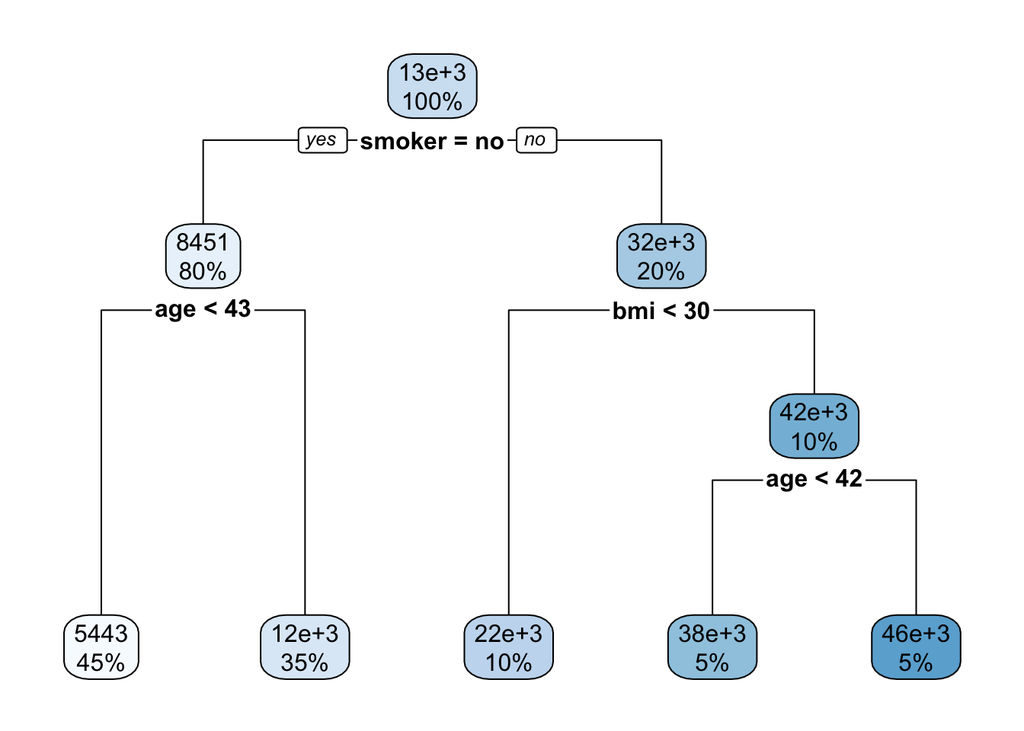

```
## n= 1003
##
## node), split, n, deviance, yval
##       * denotes terminal node
##
##  1) root 1003 144665200000 13226.820
##    2) smoker=no 799  28815690000  8451.105
##      4) age< 42.5 448  10063620000  5443.353 *
##      5) age>=42.5 351   9526323000 12290.060 *
##    3) smoker=yes 204  26252320000 31931.710
##      6) bmi< 30.01 100   2790408000 21728.410 *
##      7) bmi>=30.01 104   3040859000 41742.570
##       14) age< 41.5 53    453879700 37986.300 *
##       15) age>=41.5 51   1062033000 45646.160 *
```

On running this model on the testing data, Our test-RMSE is 4912. The first value corresponds to training RMSE. This is similar to what we’ve seen in in the interaction regression model. But but but, IT IS EASY TO INTERPRET!!!!

```
## [1] 4881.064
```

```
## [1] 4912.72
```

One disadvantage with decision tree regressor is overfitting. That doesn’t look like the case for this particular example, but our model may or may not give accurate predictions for new data. And my job here is to reduce that uncertainty, therefore I’ve decided to try the last and my favorite algorithm- The Random Forest.

## RANDOM FOREST REGRESSOR:

This algorithm works on a technique called Bagging- Bootstrapping and Aggregating. A few advantages of this algorithm over the decision tree is that it gives us consistent predictions and also reduces variation

```
##
## Call:
##  randomForest(formula = charges ~ ., data = data_rf, proximity = TRUE)
##                Type of random forest: regression
##                      Number of trees: 500
## No. of variables tried at each split: 2
##
##           Mean of squared residuals: 22107441
##                     % Var explained: 84.91
```

The RMSE for the best model(the tree which has the least RMSE) is:

```
## [1] 4696.842
```

This graph gives us an idea of how the error is reduced as we increase the number of trees in random forests. By default, it is 500 trees and coincidentally the error has not reduced further after trying more trees as well. Adding more trees also adds the cost of computing.

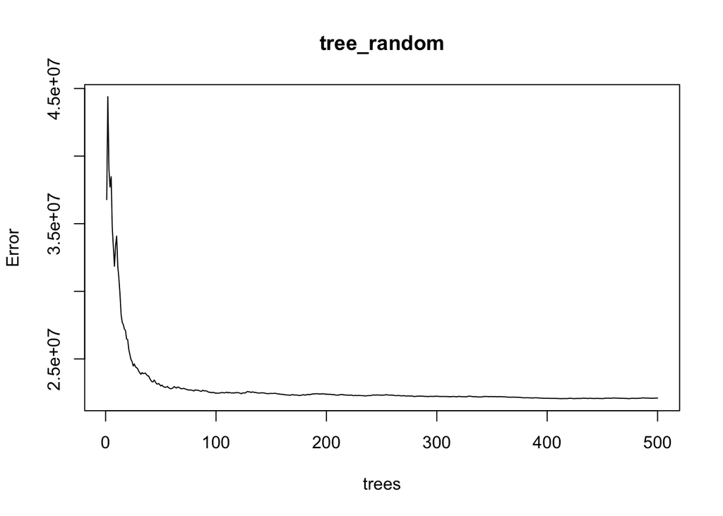

The following plot shows us how the OOB(Out-of-Bag) error varies for the number of predictors used at each decision node. By default, for regression- it is 2. But our plot tells us that using 3 predictors would fetch us minimum error.

```
## 0.01109769 0.01
## -0.03498949 0.01
## -0.05339058 0.01
```

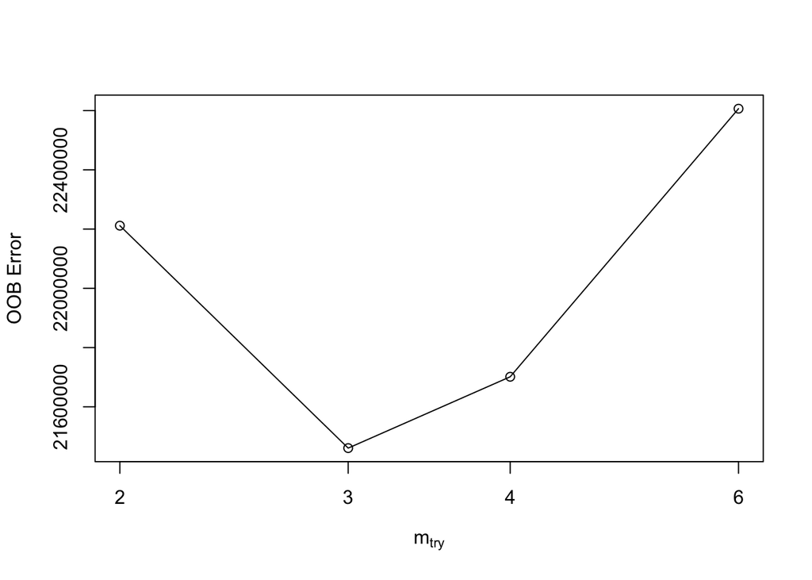

Building a model as suggested by the above analysis, we arrive at an 85% explanation of the variation and an RMSE of roughly 4600.

```
##
## Call:
##  randomForest(formula = charges ~ ., data = data_rf, mtry = 3,      proximity = TRUE)
##                Type of random forest: regression
##                      Number of trees: 500
## No. of variables tried at each split: 3
##
##           Mean of squared residuals: 21389439
##                     % Var explained: 85.4
```

```
## [1] 4618.017
```

This, ladies and gentlemen is the model that would give us the best results to address our problem.

## ATTACHING CODE BELOW

```r
knitr::opts_chunk$set(echo = FALSE)
library(data.table)
library(tidyverse)
library(car)

insurance <- read.csv("~/Downloads/insurance.csv")
head(insurance,5)
colSums(insurance==0 | insurance=='NA') # no missing values

setDT(insurance)
#str(insurance)
insurance=insurance[,c(7,1:6)]

#Lets factor the variables now
insurance_1=copy(insurance)
setDT(insurance_1)

# FACTORING VARIABLES
insurance_1$sex=as.factor(insurance_1$sex)
insurance_1$smoker=as.factor(insurance_1$smoker)
insurance_1$region=as.factor(insurance_1$region)

str(insurance_1)
summary(insurance)
library(ggplot2)
ggplot(insurance_1,aes(x=charges,fill=smoker)) + geom_histogram(bins=130,position = "dodge")
ggplot(insurance_1,aes(y=charges,x=bmi,col=smoker)) + geom_point()+geom_smooth(method='lm')
par(mfrow=c(1,2))
ggplot(insurance_1,aes(y=bmi,fill=region))+geom_boxplot() +facet_grid(~sex)
#ggplot(insurance_1,aes(y=bmi,fill=sex))+geom_boxplot() +facet_grid(~region)
ggplot(insurance,aes(x=(age<20),fill=smoker))+geom_bar(position="dodge")
ggplot(insurance,aes(y=charges,x=age,col=age<20))+geom_boxplot()+facet_grid(~smoker)
#INSERT funny gif#
#insurance_1$children=as.factor(insurance_1$children)

#insurance_1[children==3,children:="large"]
#insurance_1[children==4,children:="large"]
#insurance_1[children==5,children:="large"]

#insurance_1[children==1,children:="medium"]
#insurance_1[children==2,children:="medium"]

#insurance_1[children==0,children:="small"]
#insurance_1[,children:=factor(children)]

##str(insurance_1)
##ggplot(insurance_1,aes(x=bmi,y=charges,col=children))+geom_point(size=2)


cv_suspect=copy(insurance_1)
rm(insurance_1)
insur=copy(insurance)
#class(insur)

#table((insur$region))

insur <- mutate(insur, northeast = ifelse(region=="northeast",1,0))
insur <- mutate(insur, northwest = ifelse(region=="northwest",1,0))
insur <- mutate(insur, southeast = ifelse(region=="southeast",1,0))
insur <- mutate(insur, southwest = ifelse(region=="southwest",1,0))

insur$sex=as.factor(insur$sex)
insur$smoker=as.factor(insur$smoker)
copy1=copy(insur)
copy1=copy1[,-7]
copy1=copy1[,-10]
str(copy1)
#str(insur)
insur2=copy(insur)
insur=insur[,-7]
insur=insur[,-10]
set.seed(111)
sample <- sample.int(n = nrow(insur), size = floor(.75*nrow(insur)), replace = F)
train <- insur[sample, ]
test  <- insur[-sample, ]
rm(sample)

base_1=lm(charges~.,data=train)
summary(base_1)
rmse<-function(a,b){
  value<-sqrt(mean((a-b)^2))
  return(value)
}

rmse(train$charges,base_1$fitted.values) #RMSE TRAIN
#range(train$charges)

base1_predict=predict(base_1,newdata=test)
rmse(base1_predict,test$charges) #RMSE TEST

data1=copy(insurance)
#str(data1)
setDT(data1)

data1[,sex:=factor(sex)]
data1[,smoker:=factor(smoker)]
data1[,region:=factor(region)]
#str(data1)

library(caret)
set.seed(333)

train_control <- trainControl(method = "cv",
                              number = 10)

lm_cv <- train(charges~., data = data1,
               trControl = train_control,
               method = "lm")
print(lm_cv)
summary(lm_cv$finalModel)
rm(cv_suspect)
plot(base_1$fitted.values,base_1$residuals,col="darkgreen",pch=22)
cv_train=copy(train)
#str(train)
cv_train[,fit:=base_1$fitted.values]
cv_train[,res:=base_1$residuals]

ggplot(cv_train,aes(x=fit,y=res,col=smoker))+geom_point()
rm(cv_train)
#create partial residual plots
crPlots(base_1)
library("gridExtra")
library(ggplot2)
library(qqplotr)
shapiro.test(residuals(base_1))
hist(base_1$residuals,col='darkred',xlab="Residuals")
ggplot(mapping = aes(sample = base_1$residuals))+stat_qq_point(size = 2,color = "red")+stat_qq_line(color="green")
#insur2=copy(insur)
#insur2=insur2[,-c(3,9)]
#randmodel=lm(charges~.,data=insur2)
#summary(randmodel)

#rmse(randmodel$fitted.values,insur2$charges)
vif(base_1)
rm(base1_predict)
rm(insur)
rm(train)
rm(test)
library(data.table)
library(tidyverse)
insur=copy(insurance)
#class(insur)
#str(insur)
#table((insur$region))
#summary(insur)

# FACTORING VARIABLES
insur$sex=as.factor(insur$sex)
insur$smoker=as.factor(insur$smoker)
insur$region=as.factor(insur$region)
#str(insur)
set.seed(111)
sample <- sample.int(n = nrow(insur), size = floor(.75*nrow(insur)), replace = F)
train <- insur[sample, ]
test  <- insur[-sample, ]
rm(sample)

#head(train)
#base_1=lm(charges~.,data=train)
#summary(base_1)
rmse<-function(a,b){
  value<-sqrt(mean(((a-b))^2))
  return(value)
}

#polynomial reg
X_train <- train %>%
  select(-c(charges)) %>%
  mutate(smoker = as.numeric(smoker))%>%
  mutate(sex = as.numeric(sex))%>%
  mutate(region = as.numeric(region))
X_test <- test %>%
  select(-c(charges)) %>%
  mutate(smoker = as.numeric(smoker))%>%
  mutate(sex = as.numeric(sex))%>%
  mutate(region = as.numeric(region))


# formula which creates degree 2 terms
formula <- as.formula(
  paste(
    ' ~ .^2 + ',
    paste('poly(', colnames(X_train), ', 2, raw=TRUE)[, 2]', collapse = ' + ')
  )
)
#formula
#fitting the data to the new equation to get new dataset
train_int <- as.data.frame(model.matrix(formula, data = X_train))
test_int <- as.data.frame(model.matrix(formula, data = X_test))
#colnames(train_int)
train_int$charges = train$charges
#head(final_train)
final_train=train_int[,-c(8:13)]
final_test = test_int[,-c(8:13)]


p_lmod=lm(charges~.,final_train)
#summary(p_lmod)

#step(p_lmod, direction = "backward",trace = FALSE)
bp_lmod= lm(formula = charges ~ age + bmi + children + smoker + `age:region` +
              `sex:children` + `bmi:smoker` + `bmi:region`, data = final_train)

out.full=lm(charges~.,final_train)
out.backward=step(out.full,scope=list(lower=~1,upper=out.full),
                    direction="backward",trace=FALSE,k=2)
round(out.backward$coefficients,2)
summary(bp_lmod)$r.squared

bp_lmod_predict=predict(bp_lmod,newdata=final_test)
rmse(bp_lmod_predict,test$charges)
library(rpart)
library(rpart.plot)

insur=copy(insurance)
insur$region=as.factor(insur$region)
insur$sex=as.factor(insur$sex)
insur$smoker=as.factor(insur$smoker)

#str(insur)

set.seed(111)
sample <- sample.int(n = nrow(insur), size = floor(.75*nrow(insur)), replace = F)
train <- insur[sample, ]
test  <- insur[-sample, ]
rm(sample)

tree_1=rpart(charges~.,data=train,method="anova")


rpart.plot(tree_1,yesno=TRUE)
tree_1

train_pred=predict(tree_1,train)
rmse(train_pred,train$charges)


test_pred=predict(tree_1,test)
rmse(test_pred,test$charges)

rm(train)
rm(test)
rm(insur)
rm(ins)

rm(tweak1)
rm(cntrl)
rm(tweak2)
rm(RMSE.tweak1.test)
rm(RMSE.tweak1.train)
rm(RMSE.tweak2.test)
rm(RMSE.tweak2.train)
rm(test_pred)
rm(train_pred)
rm(tweak1_pred,tweak2_pred)
set.seed(333)
library(cowplot)
library(randomForest)
data_rf=copy(insurance)
data_rf$sex=as.factor(data_rf$sex)
data_rf$smoker=as.factor(data_rf$smoker)
data_rf$region=as.factor(data_rf$region)
#str(data_rf)
tree_random=randomForest(charges~.,data=data_rf,proximity=TRUE)

tree_random
library(party)

#which.min(tree_random$mse)
sqrt(tree_random$mse[which.min(tree_random$mse)])
plot(tree_random)
model_tuned <- tuneRF(
               x=data_rf[,-1], #define predictor variables
               y=data_rf$charges, #define response variable
               ntreeTry=500,
               mtryStart=4,
               stepFactor=1.5,
               improve=0.01,
               trace=FALSE #don't show real-time progress
               )

set.seed(141)
tree_final=randomForest(charges~.,mtry=3,data=data_rf,proximity=TRUE)
tree_final
sqrt(tree_final$mse[which.min(tree_final$mse)])
```